# DATA100 Introduction to Data Analytics

Lecture 17: Structured Relationship Between Variables

Agassi Iu

Wilfrid Laurier University

2026-11-24

## Where we left off

**Recall from last class**

We learned about a simple linear model given by the formula `y ~ x`. In this case, a model with one predictor gives a slope an interpretation of: the change in the predicted `y` when `x` goes up by 1 unit. We also applied the linear model to make predicitons using `predict()`.

Today we give the model more **structure**:

- recap a model with one numeric predictor
- add a second numeric predictor
- add a categorical predictor and check the fit with residuals
- see what the p-value in the output is telling us
- return to two numeric predictors and watch out for multicollinearity

# Recap: one numeric predictor

## Does studying help?

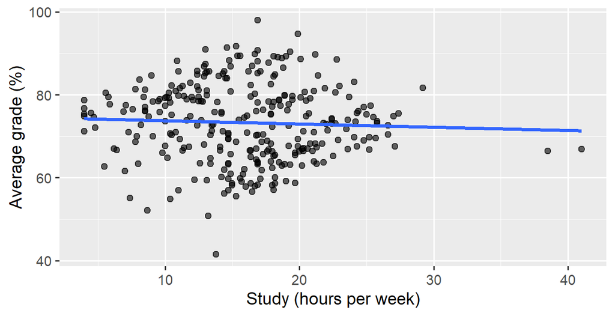

The line is flat, or even slightly downward. Does that mean studying will not help you improve your grades?

## The simple model in numbers

```r
avg_grade ~ study_hours_week
```

```
     (Intercept) study_hours_week
     74.54353601      -0.07871815
```

**Checkpoint**

In words, what do the intercept and the slope mean here? Is 0 hours of study a realistic value?

# Two numeric predictors

## More than one numeric predictor

A model can use more than one numeric predictor. List them with `+`:

```r
avg_grade ~ study_hours_week + sleep_hours
```

**The `+` is not arithmetic operation**

`study_hours_week + sleep_hours` does not add the two values together. It lists two separate predictors, each with its own coefficient.

**Holding the others fixed**

Each slope now means: the change in predicted `y` for a 1-unit increase in that predictor, with the other predictors held fixed.

## Fitting two numeric predictors

Model 1:

```r
fit.model1 <- lm(avg_grade ~ study_hours_week, data = survey)
coef(fit.model1)
```

```
     (Intercept) study_hours_week
     74.54353601      -0.07871815
```

Model 2:

```r
fit.model2 <- lm(avg_grade ~ study_hours_week + sleep_hours, data = survey)
coef(fit.model2)
```

```
     (Intercept) study_hours_week      sleep_hours
     53.51629898       0.04796112       2.86022513
```

**Checkpoint**

Compare the `study_hours_week` slope in the two models. Did it change much? How would you describe the `sleep_hours` slope in words?

**Some thoughts**

Could it be that this *average grades* cannot be solely explained by the *number of hours a student spent studying in a week*?

## Exercise

**Try it yourself**

1. Verify that `study_hour_week` on its own is not a good predictor, even with the addition of `sleep_hours` to the original model.

# One numeric and one categorical predictor

## Original Plot

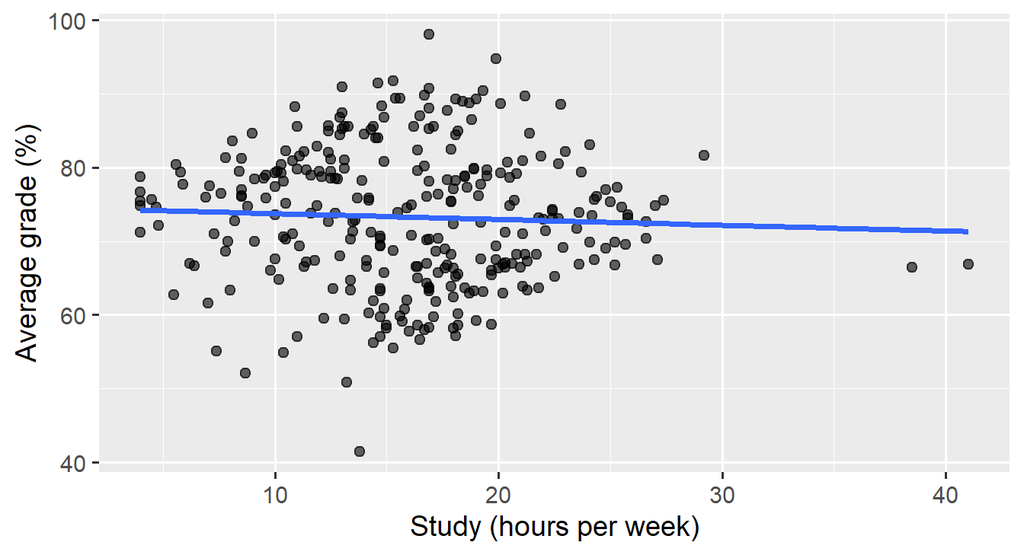

## Look at the subgroups

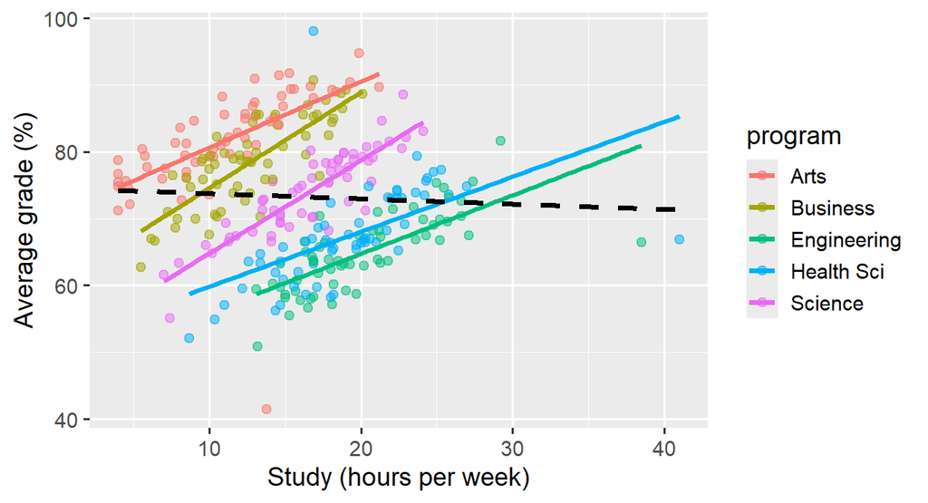

## Why are the slopes different?

```r
survey |>
  group_by(program) |>
  summarise(mean_study = mean(study_hours_week),
            mean_grade = mean(avg_grade),
            n = n())
```

```
# A tibble: 5 × 4
  program     mean_study mean_grade     n
  <chr>            <dbl>      <dbl> <int>
1 Arts              11.1       81.7    60
2 Business          12.7       78.5    60
3 Engineering       20.2       64.9    60
4 Health Sci        19.2       67.3    60
5 Science           16.6       74.0    60
```

- Programs that study more tend to have lower average grades (*a-hem Hello???*).
- Across all students, that between-program difference hides the within-program pattern.
  - Looking at the overall average may mask what is actually happening inside individual programs

## A categorical predictor

**A third-party**

A third variable (in this case, `program`) is linked to both the predictor and the outcome. Ignoring it can hide a relationship, exaggerate one, or even flip its direction.

```r
class(survey$program)
```

```
[1] "character"
```

```r
unique(survey$program)
```

```
[1] "Engineering" "Health Sci"  "Science"     "Arts"        "Business"
```

`program` is text with five possible values. Most model functions cannot use text directly, so *R* turns it into numbers behind the scenes.

## Indicator (dummy) variables

R creates a 0/1 column for each program except for one:

| program | Business | Engineering | Health Sci | Science |
| --- | --- | --- | --- | --- |
| Arts | 0 | 0 | 0 | 0 |
| Business | 1 | 0 | 0 | 0 |
| Engineering | 0 | 1 | 0 | 0 |
| Health Sci | 0 | 0 | 1 | 0 |
| Science | 0 | 0 | 0 | 1 |

**Reference level**

The left-out program is the reference level. *R* uses the first one alphabetically, which is `Arts` in this example. Every other program is used to compared with it.

**Checkpoint**

If a variable had eight categories, how many indicator columns would *R* create?

## Adding `program` to the formula

```r
avg_grade ~ study_hours_week + program
```

The `+` works the same way as before: it lists two separate predictors, each with its own coefficient. Here one is numeric and one is categorical.

## Fitting with `program`

```r
program_fit <- lm(avg_grade ~ study_hours_week + program, data = survey)
program_fit
```

```
Call:
lm(formula = avg_grade ~ study_hours_week + program, data = survey)

Coefficients:
       (Intercept)    study_hours_week     programBusiness  programEngineering
            70.084               1.048              -4.935             -26.338
 programHealth Sci      programScience
           -22.821             -13.476
```

**Checkpoint**

How does the regression output from above compare to the `study_hours_week` slope from previous example without using `program` as an explanatory variable?

## Reading the coefficients

**What has changed?**

Previously the slope for `avg_grade ~ study_hours_week` corresponds to the amount of change in average grades for every additional hours of studying. The intercept represents the average grade a student would get if they studied for 0 hours. What about now with a model such as `avg_grade ~ study_hours_week + program`?

**The study slope**

For two students **in the same program**, each extra hour of weekly study goes with this much change in predicted average grade. The comparison is “other things held fixed”.

**The program coefficients**

Each one (for example `programEngineering`) is the **difference from the reference level**, Arts. It compares students with the **same** study hours, so it shifts the whole line up or down.

**Recall: the intercept**

The intercept is the predicted grade for an `Arts` student who studies 0 hours. You might want to check whether 0 is a realistic value before reading too much into it.

## Interpreting the numbers

```r
avg_grade ~ study_hours_week + program
```

**Intercept: 70.08**

The predicted average grade for an `Arts` student (the reference level) who studies 0 hours. Nobody studies 0 hours in this data, so treat it as the line’s starting point, not a realistic prediction.

**`study_hours_week`: 1.05**

For two students in the same program, each extra hour of weekly study goes with a predicted average grade about **1.05 points higher**.

**`programBusiness`: -4.94**

For a Business student and an Arts student with the **same study hours**, the Business student’s predicted grade is about **4.9 points lower**. It is not a slope: it shifts the whole line down.

**Put it together: Business student that studies 15 hours per week**

70.08 + (1.05 × 15) + (-4.94) = **about 80.9**

## What this model looks like

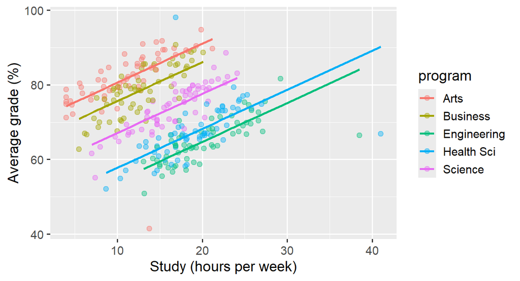

```r
survey |>
  mutate(fitted = fitted(program_fit)) |>
  ggplot(aes(x = study_hours_week, y = avg_grade, color = program)) +
  geom_point(size = 2, alpha = 0.4) +
  geom_line(aes(y = fitted), linewidth = 1) +
  labs(x = "Study (hours per week)", y = "Average grade (%)")
```

## Exercise

**More Study = Less Sleep?**

Suppose that we are interested in finding out if students have more sleep based on the amount of time they study. Would their favourite beverages (`favourite_drink`) have an influence on this answer? Complete the following tasks: 1. Fit `sleep_hours ~ study_hours_week`. Write down the slope. 2. Fit `sleep_hours ~ study_hours_week + favourite_drink`. Write down the slope. 3. Why did the slope change?

## `predict()` with a categorical predictor

```r
new_students <- data.frame(
  study_hours_week = c(10, 10, 20, 20),
  program = c("Arts", "Engineering", "Arts", "Engineering")
)
predict(program_fit, new_students)
```

```
       1        2        3        4
80.56268 54.22462 91.04119 64.70313
```

**Same machinery for new data**

The formula applies the same encoding to new data as it did to the data we used to fit the model.

## Exercise

**Try it yourself**

1. Predict the average grade for a `Science` student who studies 15 hours a week.
2. Predict it for a `Business` student with the same study hours.
3. How much do the two predictions differ? Where in the model output could you have found that?

## Why check the fit of the model?

A model gives you numbers whether or not the model is a good description. Last time we looked at p-values and residual plots to help us see whether the structure we chose fits the data.

**Checkpoint**

What would a *bad* residual plot look like?

## Revisiting p-value

If you run `summary()` on a model, you will see a p-value column.

```r
summary(program_fit)
```

```
Call:
lm(formula = avg_grade ~ study_hours_week + program, data = survey)

Residuals:
    Min      1Q  Median      3Q     Max
-43.045  -2.128   0.307   2.710  33.028

Coefficients:
                    Estimate Std. Error t value Pr(>|t|)
(Intercept)         70.08417    0.98016  71.503  < 2e-16 ***
study_hours_week     1.04785    0.06641  15.780  < 2e-16 ***
programBusiness     -4.93490    0.92081  -5.359 1.69e-07 ***
programEngineering -26.33806    1.09548 -24.043  < 2e-16 ***
programHealth Sci  -22.82052    1.05940 -21.541  < 2e-16 ***
programScience     -13.47612    0.98529 -13.677  < 2e-16 ***
---
Signif. codes:  0 '***' 0.001 '**' 0.01 '*' 0.05 '.' 0.1 ' ' 1

Residual standard error: 5.008 on 294 degrees of freedom
Multiple R-squared:  0.7152,    Adjusted R-squared:  0.7103
F-statistic: 147.6 on 5 and 294 DF,  p-value: < 2.2e-16
```

**How to read it, without the maths**

A small p-value means a pattern this clear would be *unlikely to appear by pure chance*. But it does not tell you the model fits well, and it does not tell you the relationship is causal.

## Residuals vs. fitted values

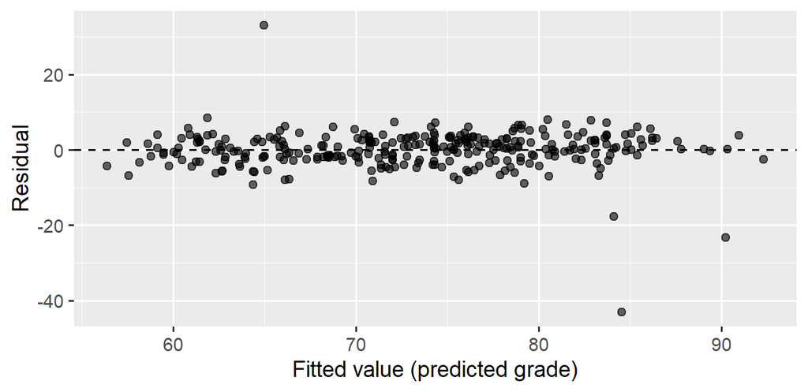

```r
survey |>
  mutate(fitted = fitted(program_fit), resid = resid(program_fit)) |>
  ggplot(aes(x = fitted, y = resid)) +
  geom_point(size = 2, alpha = 0.6) +
  geom_hline(yintercept = 0, linetype = "dashed") +
  labs(x = "Fitted value (predicted grade)", y = "Residual")
```

## The biggest residuals?

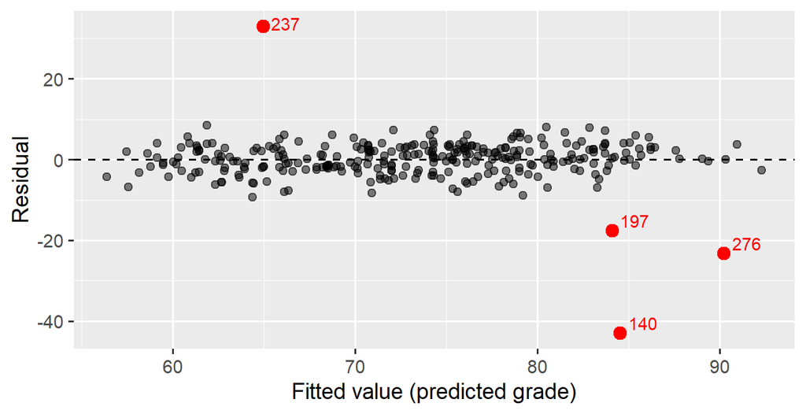

```
# A tibble: 4 × 6
     id program     study_hours_week avg_grade fitted resid
  <int> <chr>                  <dbl>     <dbl>  <dbl> <dbl>
1   140 Arts                    13.8      41.5   84.5 -43.0
2   237 Health Sci              16.9      98     65.0  33.0
3   276 Health Sci              41        66.9   90.2 -23.3
4   197 Engineering             38.5      66.4   84.1 -17.7
```

## Code for previous slide

```
diag_data <- survey |>
  mutate(id = row_number(),
         fitted = fitted(program_fit),
         resid = resid(program_fit))

outliers <- diag_data |> slice_max(abs(resid), n = 4, with_ties = FALSE)

ggplot(diag_data, aes(x = fitted, y = resid)) +
  geom_point(size = 2, alpha = 0.5) +
  geom_point(data = outliers, color = "red", size = 3.5) +
  ggrepel::geom_text_repel(data = outliers, aes(label = id), color = "red") +
  geom_hline(yintercept = 0, linetype = "dashed") +
  labs(x = "Fitted value (predicted grade)", y = "Residual")
```

## Where do they sit in the data?

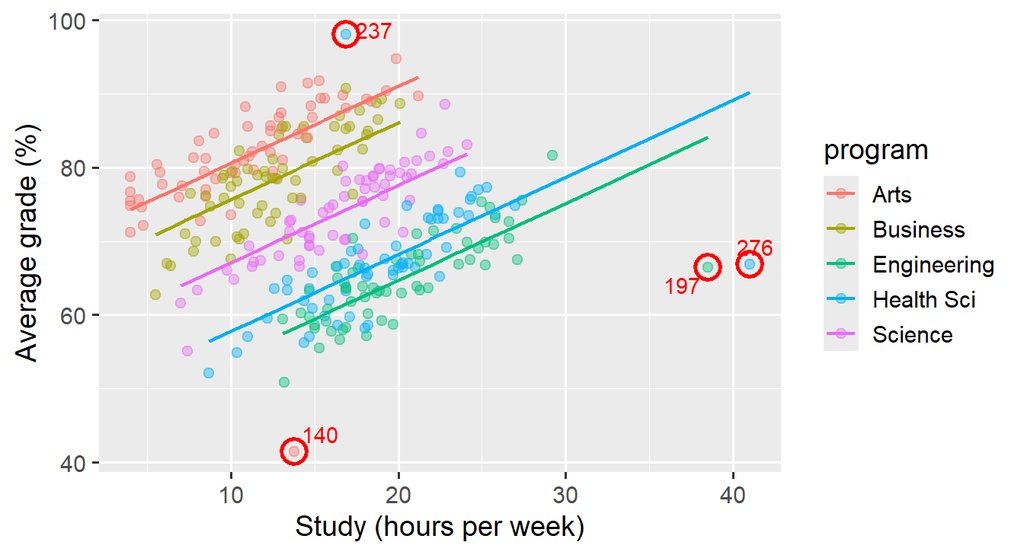

# Multicollinearity

## Multicollinearity

Earlier we added two numeric predictors to one model. But what if two predictors measure almost the same thing?

**Multicollinearity**

Two or more predictors that **move closely together**. Because they carry overlapping information, the model cannot tell which one deserves the credit.

Think of two friends who always give you the **same advice**. If a decision turns out well, who gets the credit?

**When predictors overlap**

- the individual slopes become unstable and hard to interpret
- a slope can even change size or sign when you add or drop another predictor

## Spot it before you model

The correlation between `sleep_hours` and `sleep_quality` is

```r
cor(survey$sleep_hours, survey$sleep_quality)
```

```
[1] 0.7052803
```

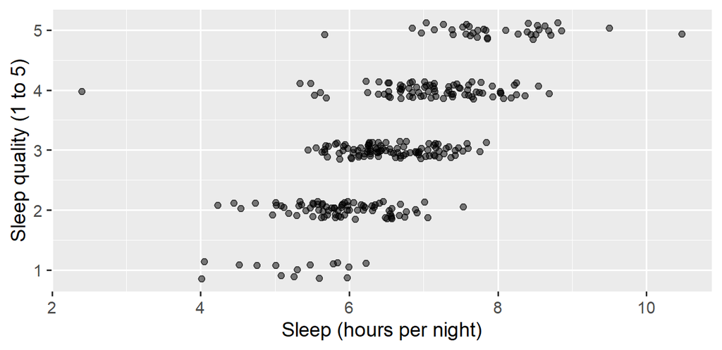

## Watch the coefficients

```r
coef(lm(avg_grade ~ sleep_hours, data = survey))
```

```
(Intercept) sleep_hours
  54.717987    2.794534
```

```r
coef(lm(avg_grade ~ sleep_quality, data = survey))
```

```
  (Intercept) sleep_quality
    68.063306      1.662045
```

```r
coef(lm(avg_grade ~ sleep_hours + sleep_quality, data = survey))
```

```
  (Intercept)   sleep_hours sleep_quality
   54.0723809     3.0528299    -0.3406475
```

**Checkpoint**

Compare each predictor’s slope **alone** with its slope **together**. What happened to `sleep_quality`? Is the new value easy to explain?

## A more extreme example

Suppose there is another survey question that recorded study time per **day**.

```r
cor(survey$study_hours_week, survey$study_hours_days)
```

```
[1] 0.9993917
```

```r
coef(summary(lm(avg_grade ~ study_hours_week, data = survey)))
```

```
                    Estimate Std. Error    t value      Pr(>|t|)
(Intercept)      74.54353601 1.62051491 45.9999075 2.106075e-137
study_hours_week -0.07871815 0.09582345 -0.8214915  4.120231e-01
```

```r
coef(summary(lm(avg_grade ~ study_hours_week + study_hours_days, data = survey)))
```

```
                  Estimate Std. Error    t value      Pr(>|t|)
(Intercept)      74.545727   1.621803 45.9647310 4.730126e-137
study_hours_week -2.075515   2.749817 -0.7547828  4.509774e-01
study_hours_days 13.975448  19.234082  0.7265981  4.680445e-01
```

**Checkpoint**

Compare the slope and the `Std. Error` of `study_hours_week` in the two models. What changed? Which version would you trust?

## Why does this happen?

With both predictors, each slope means: the change in predicted grade when one predictor goes up by 1 unit and the other stays **fixed**.

- But when weekly hours go up, daily hours go up too
- The data almost never show one changing while the other stays still
- With nothing else in this model, the model cannot split the credit: slopes become *unstable*.

**What to do about it**

- Check how strongly your predictors correlate with each other *before* modelling
- Choose one of the overlapping predictors, or combine them into a single measure

# Summary

## Summary

- A simple model with one numeric predictor gives a slope: the change in predicted `y` per 1-unit change in `x`
- With several predictors, each slope means “other parameters held fixed”
- A categorical predictor becomes indicator columns with the first level is the reference level
- Residual plots help us check whether the structure fits
- Multicollinearity: overlapping predictors make individual slopes unstable

**Next class**

More on predictive modelling. Next: how do we know a model works on data it has not seen?